# Census Data

Charmayne Patterson

7/23/2019

## Introduction

In order to explore the potential relationships between several variables related to the status of African Americans in Philadeplhia in 1847, I must start off by reading the census data.

```r
library(tidyverse) #The swiss knife!
library(RCurl) #To read the csv file from GitHub directly
```

Now that the packages are loaded, I can get the data into R.

```r
census <- read.csv("census3.csv")
```

## Exploratory Data Analysis

Now that we have ingested the data, let us start exploring it. The first thing to do is to have a quick look at our data. For that, we can use the `str()` function or the more human readable (and intuitive), `glimpse()` function.

```r
glimpse(census)
```

```
## Observations: 2,851
## Variables: 11
## $ X                 <int> 1, 2, 4, 5, 7, 9, 15, 16, 17, 19, 20, 23, 26...
## $ Family.Size       <int> 3, 3, 6, 7, 4, 3, 3, 4, 2, 6, 2, 3, 2, 4, 2,...
## $ Males             <int> 1, 2, 1, 5, 3, 1, 1, 2, 1, 4, 1, 2, 1, 2, 1,...
## $ Females           <int> 2, 1, 5, 2, 1, 2, 2, 2, 1, 2, 1, 1, 1, 2, 1,...
## $ Natives           <int> 2, 1, 2, 6, 2, 1, 1, 1, 1, 5, 0, 3, 0, 2, 0,...
## $ Not.Natives       <int> 1, 2, 4, 1, 2, 2, 2, 3, 1, 1, 2, 0, 2, 2, 2,...
## $ Male.Occupation   <fct> Watchman, 1 lab 1 Waterman, drives dray, Bar...
## $ Female.Occupation <fct> Washer, Washer, eating house, domestic dutie...
## $ Born.slaves       <int> 1, 0, 1, 0, 0, 0, 0, 0, 0, 0, 1, 0, 1, 1, 0,...
## $ Can.read          <int> 1, 1, 0, 5, 2, 1, 1, 2, 1, 5, 0, 1, 1, 3, 0,...
## $ Can.write         <int> 1, 1, 0, 5, 2, 1, 1, 2, 1, 5, 0, 2, 0, 3, 0,...
```

While carrying out any analysis, it is always best to start off with a question. It is also important to know the metadata, or the data that describes the data. For example, I see the variable `Can.read` has values ranging from 0 to 5 (we will of course check this), but I have no idea what these values mean. I would have assumed that this might be a binary value with 0 indicating the person cannot read and 1 indicating that the person can read. Or this could also mean the total number of people in a household who can read. That sounds more plausible to me. Either way, I will look at the metadata or a data dictionary, if one exists. I can also observe the different values available in the `Can.read` and `Can.write` variables.

```r
table(census$Can.read)
```

```
##
##   0   1   2   3   4   5   6   7   8   9  10  11  12  23  31
## 784 585 690 333 206 126  52  44  14   8   3   2   1   1   2
```

```r
table(census$Can.write)
```

```
##
##   0   1   2   3   4   5   6   7   8   9  11
## 976 832 511 250 116  71  51  27   9   5   3
```

Looking at this, I am now more inclined to think that these two variables show me the number of people who can read or write in a family. So with these assumptions, what are the questions that come to my mind? Personally I would really like to understand the impact of proffessions, gender and other variables available, on the level of education. For the ‘level of education’ I have two variables available, viz. `Can.read` and `Can.write`. I also know the size of a family. So perhaps it would be best to divide these two variables with the size of the family and look at this as a percentage to say what percent of a family is well versed with reading or writing. Prior to that I also want to check for discrepancies in the dataset. Given the family size, the sum of the Males and Females should be equal to the family size, considering this era only provided binary options for gender.

```r
#Create a new variable called GenderSum and then look at the difference
census <- census %>% mutate(
  GenderSum = Males + Females,
  FamDiff = `Family.Size` - GenderSum
)

which(census$FamDiff > 0)
```

```
##  [1]   71   78   95  105  145  178  295  368  421  428  432  651  787  868
## [15] 1008 1054 1487 1523 1557 1964 2472
```

```r
census <- census %>% filter(FamDiff == 0) %>% select( -GenderSum, -FamDiff)
```

Now I can mutate a new variable baased on the percentages discussed above.

```r
census <- census %>% mutate(
  Read = round((Can.read/`Family.Size`)* 100, 2),
  Write = round((Can.write/`Family.Size`)* 100, 2)
)
```

I could also perhaps combine these two newly created variables and have one cummulative variable which is just the mean of these two, to signify the overall education level. After creating this new variable I won’t need the original variables.

```r
census <- census %>% mutate(
  EduLevel = round((Read + Write)/2, 2)
)
```

I must check and see that are `EduLevel` is not greater that 100%.

```r
which(census$EduLevel > 100)
```

```
## [1]  144  165  189  238  392  475 1220
```

Looking at row 144, I see that the family size is 3, but the number of people who can read or write is 6 and 4 respectively. This alerts me to the fact that something is wrong here. I will need to filter for only those values that are less than or equal to 100.

```r
census <- census %>% filter(EduLevel <= 100) %>% select(-(Can.read:Write))
```

Ok, so far so good. Now I must address the task of making some sense of the male and female occupations. There are too many occupations and so they need to be reduced. The remainder of this analysis focuses on education level, literacy, and occupations. The data frame (census_glm.csv) below includes a variable labeled literate. If a family has above a 50% education level, then the family is literate. A (1) in the literate column specifies that a family is literate and a (0) means that the family is not literate.

```r
census_glm<- read.csv("census_glm.csv")
```

Additional variables are included in the data file. These variables are removed using the code that follows.

```r
census_glm<-select(census_glm, -c(X.1, X))
```

1. What was the most common profession for males?
2. Waht was the most common profession for females?
3. How do these professions measure up when viewed from the education level?
4. Which is the least educated profession?
5. Which is the most educated profession?
6. Is there a relationship between family size and Education Level?
7. Is there any diﬀerence between genders as far as education level is concerned?
8. Does being born a slave have any bearing on the education level?

```r
census_glm %>% group_by(Male.Occupation) %>% count() %>% arrange(desc(n))
```

```
## # A tibble: 1,426 x 2
## # Groups:   Male.Occupation [1,426]
##    Male.Occupation     n
##    <fct>           <int>
##  1 porter             93
##  2 waiter             72
##  3 laborer            70
##  4 seaman             46
##  5 hod carrier        38
##  6 barber             36
##  7 waiter $10m        31
##  8 various            28
##  9 Laborer $5w        27
## 10 Rag & Bone         25
## # ... with 1,416 more rows
```

```r
census_glm %>% group_by(Female.Occupation) %>% count() %>% arrange(desc(n))
```

```
## # A tibble: 796 x 2
## # Groups:   Female.Occupation [796]
##    Female.Occupation     n
##    <fct>             <int>
##  1 washer              392
##  2 Washing & Ironing   302
##  3 days work           192
##  4 Washing             116
##  5 dom. duties         114
##  6 House Work           62
##  7 2 washers            49
##  8 Days Work            35
##  9 sempstress           32
## 10 dress maker          31
## # ... with 786 more rows
```

The occupation with the largest number of males is porter. Since there are 1,426 different occupations, a filter is created to include only occupations that have at least 20 male family members. When viewing the occupations for females, it seems that more females seem to hold a position than males. This observation was fascinating to me as the male in modern times are viewed as the family provider. The most popular female position held is a washer. There are 392 women washers in the data set. Since there are 796 different occupations, a filter is created to include only occupations that have at least 20 female family members.The results are printed to the consoloe.

```r
male.occ_count <- census_glm %>% group_by(Male.Occupation) %>% count() %>% filter(n > 19) %>% arrange(desc(n))
female.occ_count <- census_glm %>% group_by(Female.Occupation) %>% count() %>% filter(n > 19) %>% arrange(desc(n))
male.occ_count
```

```
## # A tibble: 14 x 2
## # Groups:   Male.Occupation [14]
##    Male.Occupation     n
##    <fct>           <int>
##  1 porter             93
##  2 waiter             72
##  3 laborer            70
##  4 seaman             46
##  5 hod carrier        38
##  6 barber             36
##  7 waiter $10m        31
##  8 various            28
##  9 Laborer $5w        27
## 10 Rag & Bone         25
## 11 Laborer $4w        23
## 12 clothes dealer     21
## 13 Jobbing            20
## 14 Laborer $6w        20
```

```r
female.occ_count
```

```
## # A tibble: 15 x 2
## # Groups:   Female.Occupation [15]
##    Female.Occupation     n
##    <fct>             <int>
##  1 washer              392
##  2 Washing & Ironing   302
##  3 days work           192
##  4 Washing             116
##  5 dom. duties         114
##  6 House Work           62
##  7 2 washers            49
##  8 Days Work            35
##  9 sempstress           32
## 10 dress maker          31
## 11 service              27
## 12 Rag & Bone           25
## 13 washer when able     25
## 14 domestic duties      22
## 15 House Cleaning       20
```

This filter seems to be a good one. Now take a deeper dive into the data to determine education level by occupation. A comparison among occupations answers question 1. The results will be displayed as a bar graph.

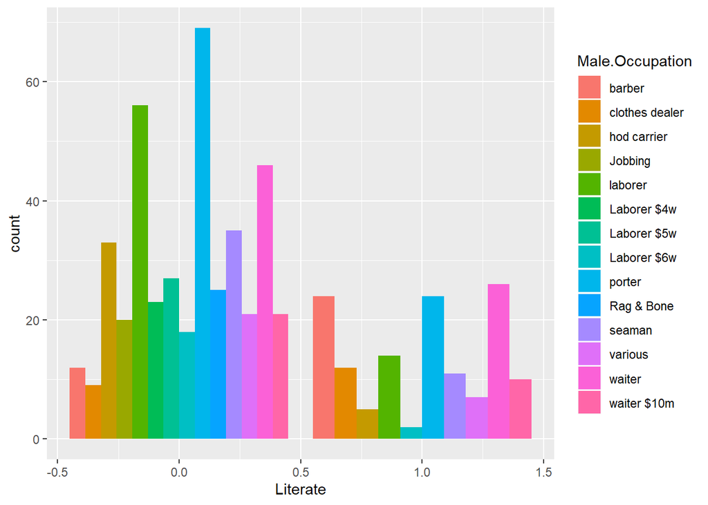

```r
ggplot(census_glm %>% filter(Male.Occupation %in% unique(male.occ_count$Male.Occupation)),
       aes(x = Literate, fill = Male.Occupation)) + geom_bar(position = 'dodge')
```

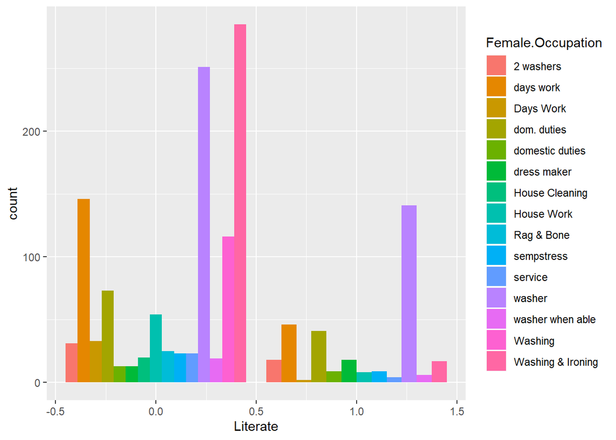

```r
ggplot(census_glm %>% filter(Female.Occupation %in% unique(female.occ_count$Female.Occupation)),
       aes(x = Literate, fill = Female.Occupation)) + geom_bar(position = 'dodge')
```

Attention is shifting to determining a relationship between the variables. We observe the relationship between family size and education level. A color scheme is used to distinguish between the literate and non-literate group easily.

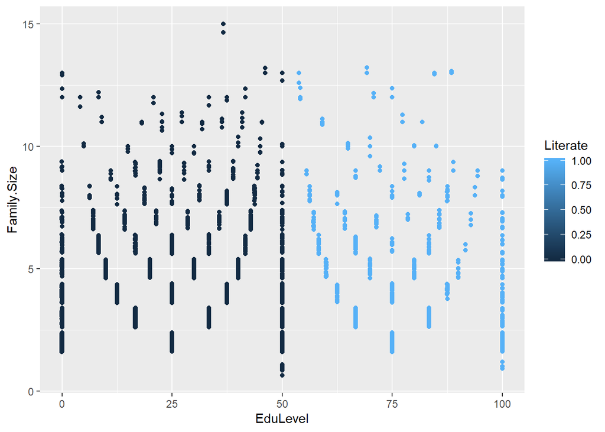

```r
ggplot(census_glm, aes(x = EduLevel, y = Family.Size, color=Literate)) +

  geom_point() + geom_jitter()
```

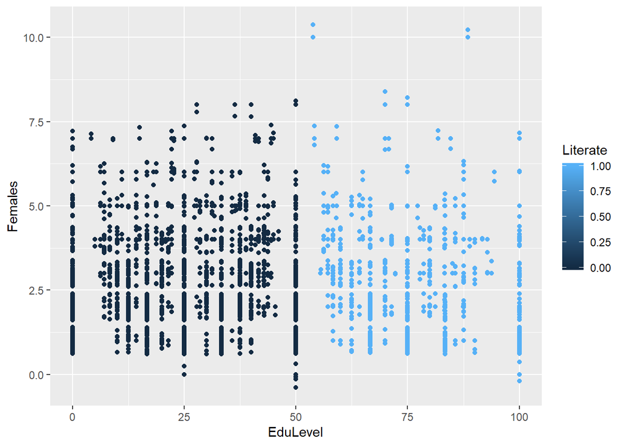

```r
ggplot(census_glm, aes(x = EduLevel, y = Females, color=Literate)) +

  geom_point() + geom_jitter()
```

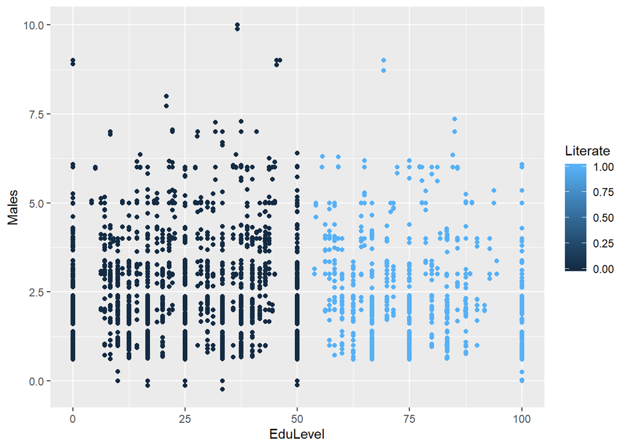

```r
ggplot(census_glm, aes(x = EduLevel, y = Males, color=Literate)) +

  geom_point() + geom_jitter()
```

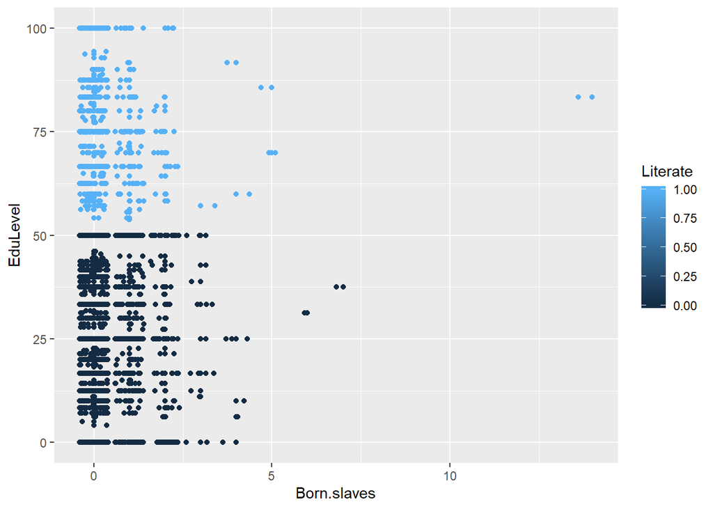

```r
ggplot(census_glm, aes(x = Born.slaves, y = EduLevel, color=Literate)) +

  geom_point() + geom_jitter()
```

Consider question number 8, we draw a table to capture information to answer the question and to confirm the results from the graph above.

```r
census_glm %>% group_by(Literate, Born.slaves) %>% count()
```

```
## # A tibble: 14 x 3
## # Groups:   Literate, Born.slaves [14]
##    Literate Born.slaves     n
##       <int>       <int> <int>
##  1        0           0  1710
##  2        0           1   301
##  3        0           2   102
##  4        0           3    19
##  5        0           4     6
##  6        0           6     1
##  7        0           7     1
##  8        1           0   514
##  9        1           1    87
## 10        1           2    26
## 11        1           3     1
## 12        1           4     2
## 13        1           5     3
## 14        1          14     1
```